# Estimativas de variação de bolsas PROEX

# Metodologia

- Dados usados: base de dados abertos CAPES (planilhas de discentes, docentes e programas por ano), GeoCapes(bolsa por programa em 2018), PNUD (idh)
- Cotas de bolsas calculadas para cada programa conforme anexos I, II , III das portarias 20 e 21 de 2020 da CAPES
- Número de bolsas estimado aplicando-se os limites de no máximo 10% de redução ou 30% de aumento, sobre o número de bolsas de cada programa em 2018. Esta é a melhor aproximação que podemos fazer, pois a CAPES não disponibilizou o número de bolsas por programa em 2019 ou antes e depois das protarias.
- Para programas PROEX deve ser uma estimativa boa, pois estes programas não sofreram cortes de bolsas em 2019. Pequenas diferenças podem ocorrer porque os programas PROEX podem converter duas bolsas de mestrado em uma de doutorado, conforme suas necessidades. Assim, é possível que haja pequenas diferenças entre o número de cotas de bolsas de cada tipo em 2018 e as de fevereiro de 2020. mas acreditamos que stas diferenças sejam pequenas.

# Achados

## O total de bolsas PROEX teve um discreto aumento

N de bolsas em 2018 e estimado para 2020

|  | Mestrado | Doutorado |
| --- | --- | --- |
| bolsas.em.2018 | 8231 | 12351 |
| est.bolsas.2020 | 8488 | 12607 |

## Houve perdas em áreas de avaliação

### Saldo de bolsas

Bolsas de doutorado: número em 2018, estimativa para 2020, diferença absoluta e percentual em relação a 2018

| NM_AREA_AVALIACAO | N.18 | N.20 | diferenca | dif.p |
| --- | --- | --- | --- | --- |
| MATERIAIS | 131 | 117 | -14 | -10.7 |
| ANTROPOLOGIA / ARQUEOLOGIA | 90 | 83 | -7 | -7.8 |
| QUÍMICA | 753 | 706 | -47 | -6.2 |
| SOCIOLOGIA | 176 | 165 | -11 | -6.2 |
| CIÊNCIAS DA RELIGIÃO E TEOLOGIA | 19 | 18 | -1 | -5.3 |
| CIÊNCIA DA COMPUTAÇÃO | 417 | 396 | -21 | -5.0 |
| FILOSOFIA | 167 | 160 | -7 | -4.2 |
| HISTÓRIA | 213 | 204 | -9 | -4.2 |
| LINGUÍSTICA E LITERATURA | 513 | 494 | -19 | -3.7 |
| FARMÁCIA | 238 | 231 | -7 | -2.9 |
| BIODIVERSIDADE | 635 | 621 | -14 | -2.2 |
| EDUCAÇÃO | 378 | 372 | -6 | -1.6 |
| ZOOTECNIA / RECURSOS PESQUEIROS | 287 | 283 | -4 | -1.4 |
| ENGENHARIAS II | 587 | 584 | -3 | -0.5 |
| MATEMÁTICA / PROBABILIDADE E ESTATÍSTICA | 287 | 286 | -1 | -0.3 |
| ENGENHARIAS IV | 401 | 403 | 2 | 0.5 |
| GEOGRAFIA | 210 | 211 | 1 | 0.5 |
| CIÊNCIAS BIOLÓGICAS I | 398 | 401 | 3 | 0.8 |
| SERVIÇO SOCIAL | 125 | 126 | 1 | 0.8 |
| PSICOLOGIA | 205 | 207 | 2 | 1.0 |
| CIÊNCIA POLÍTICA E RELAÇÕES INTERNACIONAIS | 149 | 151 | 2 | 1.3 |
| CIÊNCIAS BIOLÓGICAS III | 291 | 296 | 5 | 1.7 |
| BIOTECNOLOGIA | 149 | 152 | 3 | 2.0 |
| MEDICINA VETERINÁRIA | 337 | 344 | 7 | 2.1 |
| COMUNICAÇÃO E INFORMAÇÃO | 119 | 122 | 3 | 2.5 |
| CIÊNCIAS AGRÁRIAS I | 772 | 793 | 21 | 2.7 |
| ARTES | 133 | 137 | 4 | 3.0 |
| ASTRONOMIA / FÍSICA | 372 | 386 | 14 | 3.8 |
| ENGENHARIAS III | 248 | 258 | 10 | 4.0 |
| CIÊNCIA DE ALIMENTOS | 144 | 150 | 6 | 4.2 |
| ECONOMIA | 174 | 182 | 8 | 4.6 |
| MEDICINA I | 319 | 335 | 16 | 5.0 |
| INTERDISCIPLINAR | 274 | 288 | 14 | 5.1 |
| ADMINISTRAÇÃO PÚBLICA E DE EMPRESAS, CIÊNCIAS CONTÁBEIS E TURISMO | 98 | 104 | 6 | 6.1 |
| CIÊNCIAS BIOLÓGICAS II | 515 | 550 | 35 | 6.8 |
| MEDICINA III | 71 | 76 | 5 | 7.0 |
| CIÊNCIAS AMBIENTAIS | 110 | 118 | 8 | 7.3 |
| ODONTOLOGIA | 301 | 325 | 24 | 8.0 |
| ENGENHARIAS I | 189 | 206 | 17 | 9.0 |
| ARQUITETURA, URBANISMO E DESIGN | 61 | 67 | 6 | 9.8 |
| NUTRIÇÃO | 61 | 67 | 6 | 9.8 |
| MEDICINA II | 260 | 286 | 26 | 10.0 |
| EDUCAÇÃO FÍSICA | 137 | 151 | 14 | 10.2 |
| GEOCIÊNCIAS | 215 | 243 | 28 | 13.0 |
| DIREITO | 144 | 164 | 20 | 13.9 |
| PLANEJAMENTO URBANO E REGIONAL / DEMOGRAFIA | 58 | 68 | 10 | 17.2 |
| ENSINO | 84 | 101 | 17 | 20.2 |
| SAÚDE COLETIVA | 230 | 284 | 54 | 23.5 |
| ENFERMAGEM | 106 | 135 | 29 | 27.4 |

Bolsas de mestrado: número em 2018, estimativa para 2020, diferença absoluta e percentual em relação a 2018

| NM_AREA_AVALIACAO | N.18 | N.20 | diferenca | dif.p |
| --- | --- | --- | --- | --- |
| MATERIAIS | 78 | 70 | -8 | -10.3 |
| LINGUÍSTICA E LITERATURA | 428 | 399 | -29 | -6.8 |
| PLANEJAMENTO URBANO E REGIONAL / DEMOGRAFIA | 46 | 43 | -3 | -6.5 |
| QUÍMICA | 454 | 425 | -29 | -6.4 |
| PSICOLOGIA | 159 | 150 | -9 | -5.7 |
| COMUNICAÇÃO E INFORMAÇÃO | 92 | 88 | -4 | -4.3 |
| ENGENHARIAS III | 293 | 281 | -12 | -4.1 |
| HISTÓRIA | 109 | 105 | -4 | -3.7 |
| CIÊNCIAS BIOLÓGICAS III | 191 | 190 | -1 | -0.5 |
| ANTROPOLOGIA / ARQUEOLOGIA | 54 | 54 | 0 | 0.0 |
| ARQUITETURA, URBANISMO E DESIGN | 56 | 56 | 0 | 0.0 |
| ECONOMIA | 153 | 153 | 0 | 0.0 |
| NUTRIÇÃO | 51 | 51 | 0 | 0.0 |
| ZOOTECNIA / RECURSOS PESQUEIROS | 181 | 181 | 0 | 0.0 |
| GEOCIÊNCIAS | 210 | 211 | 1 | 0.5 |
| CIÊNCIA DA COMPUTAÇÃO | 322 | 324 | 2 | 0.6 |
| CIÊNCIAS BIOLÓGICAS II | 299 | 301 | 2 | 0.7 |
| EDUCAÇÃO FÍSICA | 126 | 127 | 1 | 0.8 |
| ENGENHARIAS IV | 403 | 407 | 4 | 1.0 |
| GEOGRAFIA | 151 | 153 | 2 | 1.3 |
| CIÊNCIA DE ALIMENTOS | 70 | 71 | 1 | 1.4 |
| ENGENHARIAS I | 249 | 253 | 4 | 1.6 |
| FILOSOFIA | 63 | 64 | 1 | 1.6 |
| BIOTECNOLOGIA | 91 | 93 | 2 | 2.2 |
| BIODIVERSIDADE | 363 | 372 | 9 | 2.5 |
| FARMÁCIA | 115 | 118 | 3 | 2.6 |
| EDUCAÇÃO | 215 | 222 | 7 | 3.3 |
| MEDICINA VETERINÁRIA | 236 | 248 | 12 | 5.1 |
| ENSINO | 74 | 78 | 4 | 5.4 |
| MEDICINA II | 185 | 195 | 10 | 5.4 |
| MEDICINA III | 32 | 34 | 2 | 6.2 |
| SOCIOLOGIA | 95 | 101 | 6 | 6.3 |
| ENGENHARIAS II | 414 | 441 | 27 | 6.5 |
| CIÊNCIAS AGRÁRIAS I | 483 | 518 | 35 | 7.2 |
| INTERDISCIPLINAR | 138 | 149 | 11 | 8.0 |
| ODONTOLOGIA | 163 | 177 | 14 | 8.6 |
| SERVIÇO SOCIAL | 81 | 88 | 7 | 8.6 |
| ASTRONOMIA / FÍSICA | 228 | 248 | 20 | 8.8 |
| ARTES | 87 | 95 | 8 | 9.2 |
| CIÊNCIAS BIOLÓGICAS I | 158 | 174 | 16 | 10.1 |
| MATEMÁTICA / PROBABILIDADE E ESTATÍSTICA | 132 | 148 | 16 | 12.1 |
| ADMINISTRAÇÃO PÚBLICA E DE EMPRESAS, CIÊNCIAS CONTÁBEIS E TURISMO | 69 | 79 | 10 | 14.5 |
| CIÊNCIAS AMBIENTAIS | 48 | 55 | 7 | 14.6 |
| CIÊNCIA POLÍTICA E RELAÇÕES INTERNACIONAIS | 57 | 66 | 9 | 15.8 |
| ENFERMAGEM | 87 | 101 | 14 | 16.1 |
| DIREITO | 142 | 169 | 27 | 19.0 |
| MEDICINA I | 149 | 178 | 29 | 19.5 |
| SAÚDE COLETIVA | 141 | 171 | 30 | 21.3 |
| CIÊNCIAS DA RELIGIÃO E TEOLOGIA | 10 | 13 | 3 | 30.0 |

# A região Sul foi a que perdeu mais e a SE a que ganhou mais

### Saldo de bolsas

Bolsas de doutorado

| NM_REGIAO | N.18 | N.20 | diferenca | dif.p |
| --- | --- | --- | --- | --- |
| CENTRO-OESTE | 371 | 389 | 18 | 4.9 |
| NORDESTE | 854 | 914 | 60 | 7.0 |
| NORTE | 115 | 112 | -3 | -2.6 |
| SUDESTE | 7806 | 8131 | 325 | 4.2 |
| SUL | 3205 | 3061 | -144 | -4.5 |

Bolsas de mestrado

| NM_REGIAO | N.18 | N.20 | diferenca | dif.p |
| --- | --- | --- | --- | --- |
| CENTRO-OESTE | 218 | 239 | 21 | 9.6 |
| NORDESTE | 577 | 623 | 46 | 8.0 |
| NORTE | 76 | 79 | 3 | 3.9 |
| SUDESTE | 5148 | 5388 | 240 | 4.7 |
| SUL | 2212 | 2159 | -53 | -2.4 |

### N de programas que perderam bolsas

Se consideramos % de programas com perdas, a região SE supera o NE, mas está próxima. Sul continua sendo a região mais afetada.

Bolsas de doutorado: número de programas que tiveram perdas de bolsas

| NM_REGIAO | Total.programas | Programas.que.perderam | proporcao.perderam |
| --- | --- | --- | --- |
| SUL | 105 | 71 | 67.6 |
| NORTE | 5 | 3 | 60.0 |
| SUDESTE | 318 | 130 | 40.9 |
| NORDESTE | 37 | 12 | 32.4 |
| CENTRO-OESTE | 20 | 6 | 30.0 |

| NM_REGIAO | Total.programas | Programas.que.perderam | proporcao.perderam |
| --- | --- | --- | --- |
| SUL | 104 | 63 | 60.6 |
| NORTE | 5 | 2 | 40.0 |
| SUDESTE | 313 | 109 | 34.8 |
| NORDESTE | 37 | 11 | 29.7 |
| CENTRO-OESTE | 20 | 3 | 15.0 |

# As perdas se concentram nos programas que tinham maior número de bolsas

O padrão mais claro que há nos dados é este. Separando os programas em três classes de número bolsas de doutorado em múltiplos de 21 (valor inicial para programas 7), vemos que a maioria dos programas que tinham até 21 bolsas em 2018 ganharam mais bolsas. E que programas que tinham mais que 21, e principalmente os que tinham mais que 42 bolsas em sua maioria perderam.

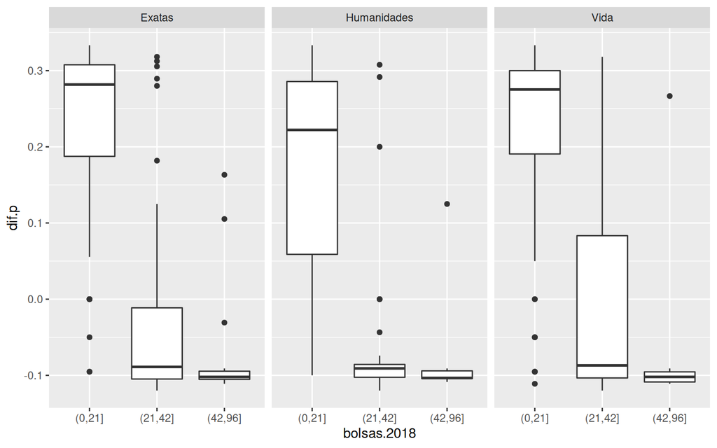

O padrão se repete para bolsas de mestrado, agregadas em classes múltiplas de 14 bolsas:

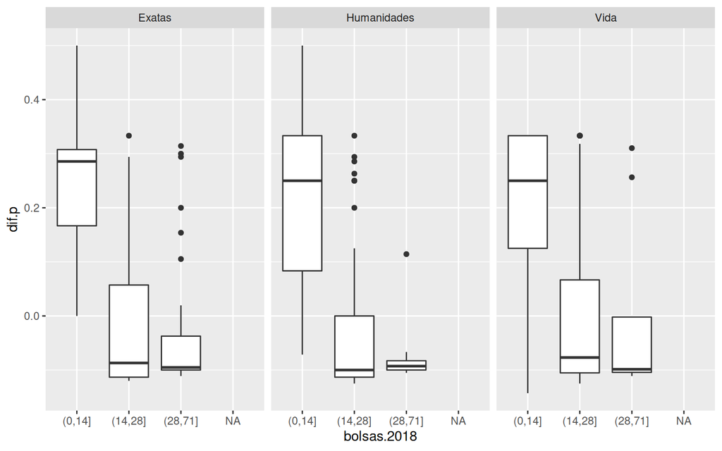

# As relações com IDH alto e Média de titulados não são claras

Em parte deve-se à baixa variação de IDH das cidade em que há programas PROEX. Mas acredito que a principal razão é o padrão da seção acima: por causa dos valores iniciais da ordem de 14-20 combinados com os limites, programas que tinham muitas bolsas sempre terão que ter os 10% de perda, mesmo quando “ganham” cotas em relação ao valor inicial. Este programas com muitas bolsas são os maiores, que também têm mais discentes, docentes e portanto titulados. Apesar do maior número de titulados, a maioria teve redução de 10% das bolsas, pq tinha muito mais que o valor inicial.

### Doutorado

Bolsas de doutorado: número em 2018, estimativa para 2020, diferença absoluta e percentual em relação a 2018

| idhm.faixa | tmc.faixa | N.18 | N.20 | diferenca | dif.p |
| --- | --- | --- | --- | --- | --- |
| Alto | Alta | 1159 | 1305 | 146 | 12.6 |
| Alto | Baixa | 54 | 52 | -2 | -3.7 |
| Alto | Media | 2838 | 3039 | 201 | 7.1 |
| Alto | Muito Alta | 96 | 125 | 29 | 30.2 |
| Medio | Media | 58 | 60 | 2 | 3.4 |
| Muito Alto | Alta | 2189 | 2154 | -35 | -1.6 |
| Muito Alto | Baixa | 9 | 10 | 1 | 11.1 |
| Muito Alto | Media | 5113 | 4987 | -126 | -2.5 |
| Muito Alto | Muito Alta | 835 | 875 | 40 | 4.8 |

Bolsas de doutorado: número de programas que tiveram perdas

| idhm.faixa | tmc.faixa | Total.programas | Programas.que.perderam | proporcao.perderam |
| --- | --- | --- | --- | --- |
| Alto | Alta | 41 | 8 | 19.5 |
| Alto | Baixa | 4 | 2 | 50.0 |
| Alto | Media | 131 | 42 | 32.1 |
| Alto | Muito Alta | 3 | 0 | 0.0 |
| Medio | Media | 2 | 0 | 0.0 |
| Muito Alto | Alta | 63 | 34 | 54.0 |
| Muito Alto | Baixa | 1 | 0 | 0.0 |
| Muito Alto | Media | 224 | 130 | 58.0 |
| Muito Alto | Muito Alta | 16 | 6 | 37.5 |

### Mestrado

Bolsas de mestrado: número em 2018, estimativa para 2020, diferença absoluta e percentual em relação a 2018

| idhm.faixa | tmc.faixa | N.18 | N.20 | diferenca | dif.p |
| --- | --- | --- | --- | --- | --- |
| Alto | Alta | 1039 | 1075 | 36 | 3.5 |
| Alto | Baixa | 50 | 58 | 8 | 16.0 |
| Alto | Media | 1743 | 1923 | 180 | 10.3 |
| Alto | Muito Alta | 180 | 218 | 38 | 21.1 |
| Medio | Media | 42 | 44 | 2 | 4.8 |
| Muito Alto | Alta | 1167 | 1167 | 0 | 0.0 |
| Muito Alto | Baixa | 71 | 73 | 2 | 2.8 |
| Muito Alto | Media | 3129 | 3079 | -50 | -1.6 |
| Muito Alto | Muito Alta | 810 | 851 | 41 | 5.1 |

Bolsas de mestrado: número de programas que tiveram perdas

| idhm.faixa | tmc.faixa | Total.programas | Programas.que.perderam | proporcao.perderam |
| --- | --- | --- | --- | --- |
| Alto | Alta | 41 | 15 | 36.6 |
| Alto | Baixa | 7 | 1 | 14.3 |
| Alto | Media | 126 | 26 | 20.6 |
| Alto | Muito Alta | 5 | 0 | 0.0 |
| Medio | Media | 2 | 1 | 50.0 |
| Muito Alto | Alta | 51 | 26 | 51.0 |
| Muito Alto | Baixa | 12 | 4 | 33.3 |
| Muito Alto | Media | 213 | 106 | 49.8 |
| Muito Alto | Muito Alta | 22 | 9 | 40.9 |

2020-03-05